# Assignment 15

Anthony Cunningham

```r
knitr::opts_chunk$set(echo = TRUE, warning = FALSE, message = FALSE)

# Change working dir in RMarkdown cell
knitr::opts_knit$set(root.dir =
'C:/Users/AC069015/kumc_applied_stats/data_824_data_viz_and_acquisition'
)

library(dplyr)
library(tidyr)
library(ggplot2)
library(readr)
library(datasets)
library(readxl)
library(circlize)
library(FactoMineR)
library(factoextra)
library(pheatmap)
library(cluster)
library(factoextra)
```

# Exercise 1

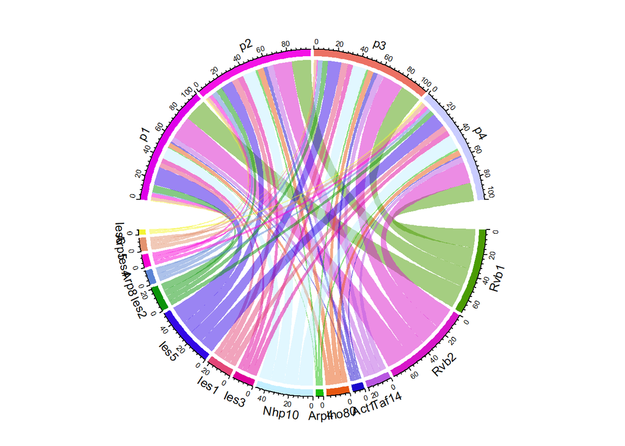

```r
dta <- read_excel("datasets/Interaction_proteins.xls", skip=1)

dta_new <- dta %>% mutate(
    p1 = rowMeans(select(., contains("_P1")))*100,
    p2 = rowMeans(select(., contains("_P2")))*100,
    p3 = rowMeans(select(., contains("_P3")))*100,
    p4 = rowMeans(select(., contains("_P4")))*100
) %>% select(p1, p2, p3, p4)

rownames(dta_new) <-dta$Proteins
chordDiagram(as.matrix(dta_new))
```

# Exercise 2

Examples of Missing Data Structures:

- MCAR: Blood pressure monitor malfunctions at random times, resulting in blood pressure measures not being recorded for some routine patient visits.
- MAR: An overworked nurse in the emergency department doesn’t capture patient weight or blood pressure measurements during very busy periods in order to maximize patient throughput. While missingness of these measures aren’t related to the values themselves, they are missing for non-random patients (associated with time and missingness of the other measures that are also not captured).
- MNAR: An outpatient clinic asks all patients about whether (and to what extent) they use tobacco, marijuana, alcohol and hard drugs. It’s plausible that users of substances that are banned or illegal in the clinic’s area are more likely to not answer this question than non-users (i.e. response is missing), for fear of disclosure to law enforcement agencies.

# Exercise 3

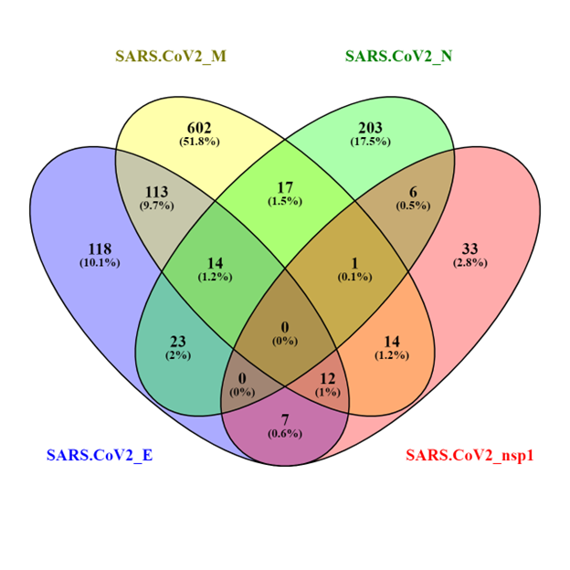

Venn Diagram

# Exercise 4

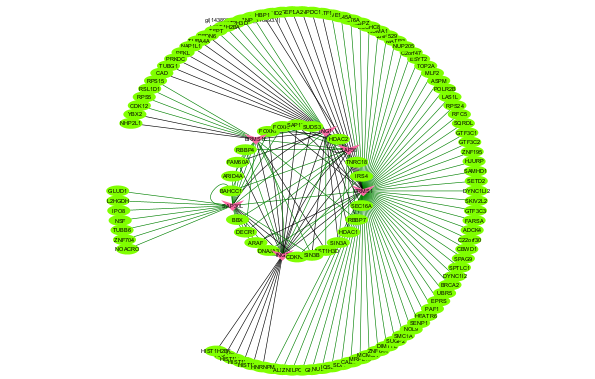

Network Graph – Circular Layout

Network Properties:

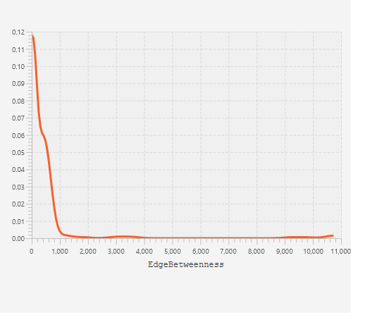

- Diameter = 4, which indicates that this network is not very extensive: the maximum number of nodes that the 2 nodes furthest away from each other is is 4.
- Avg. Path Length = 2.267, again, indicating a shallow network.

# Exercise 5

- Use any data (iris is a good data) to visualize the relationship between variables using PCA, CA, or MCA.

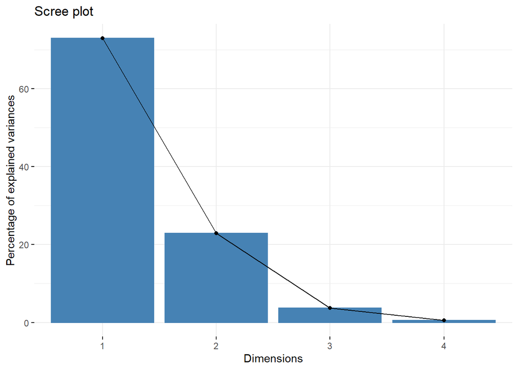

```r
data("iris")

res.PCA <- PCA(iris %>% select(-Species), graph = FALSE)
fviz_eig(res.PCA)
```

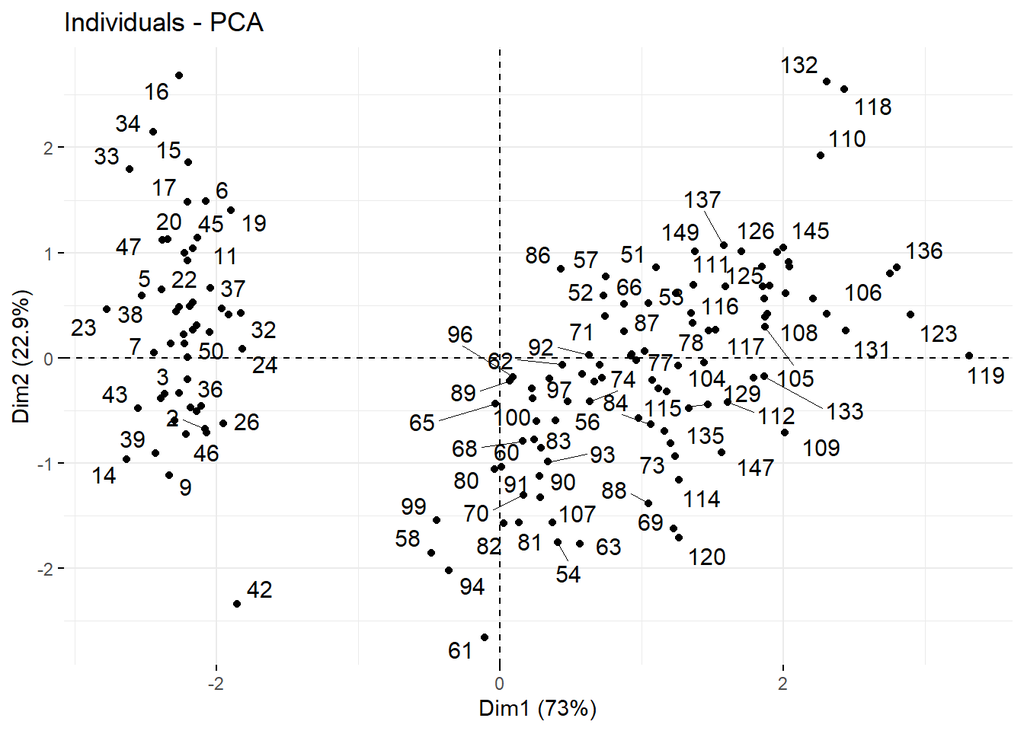

```r
fviz_pca_ind(res.PCA, repel = TRUE)
```

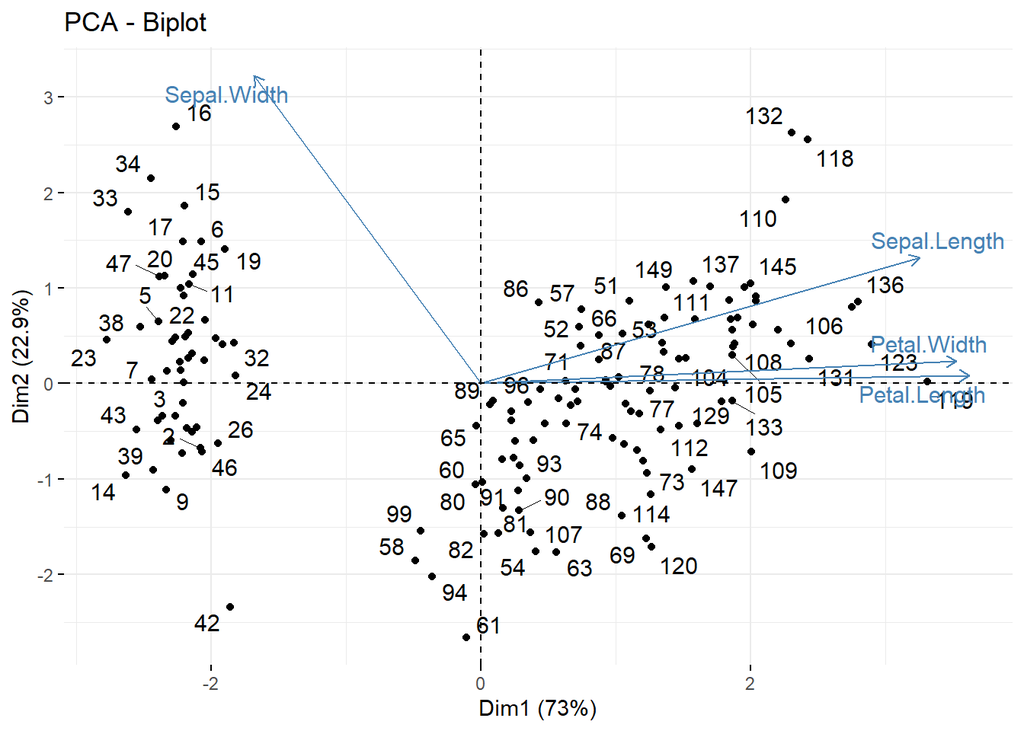

```r
fviz_pca_biplot(res.PCA, repel = TRUE)
```

- Use any data to visualize variables and observations using heat map and hierarchical clustering method. You can use the same data that you used when doing clustering in Clustvis.

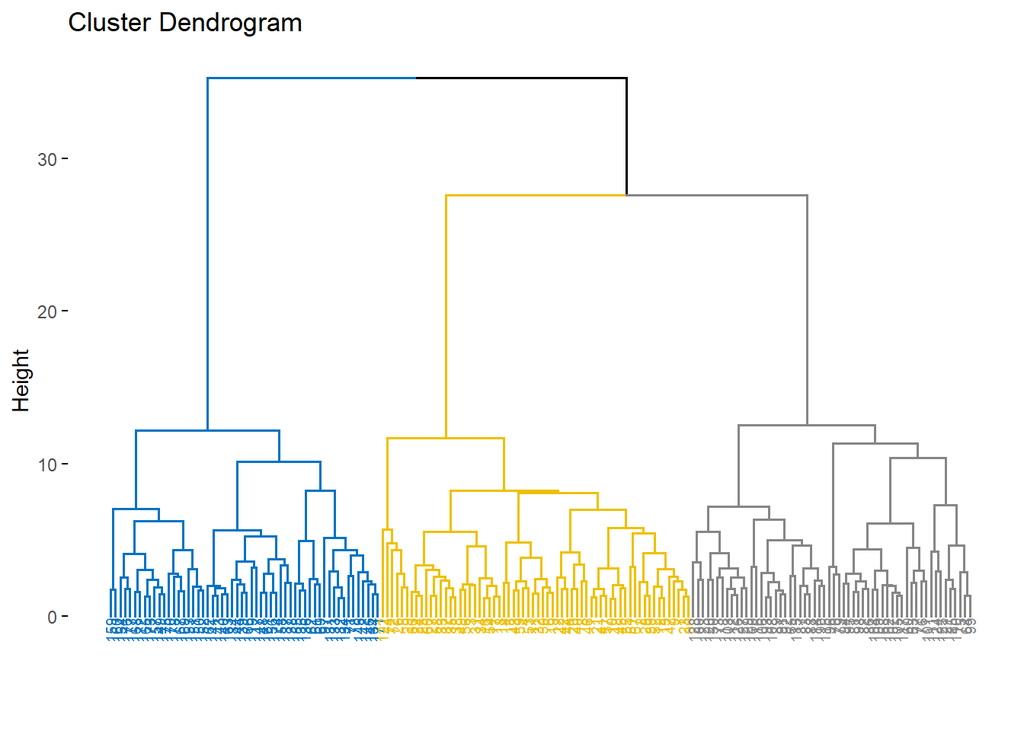

```r
wine <- read_csv("datasets/wine-clustering.csv")
wine_scaled <- scale(wine)

res.hc <- hclust(dist(wine_scaled), method = "ward.D2")
fviz_dend(res.hc, cex=0.5, k=3, palette="jco")
```

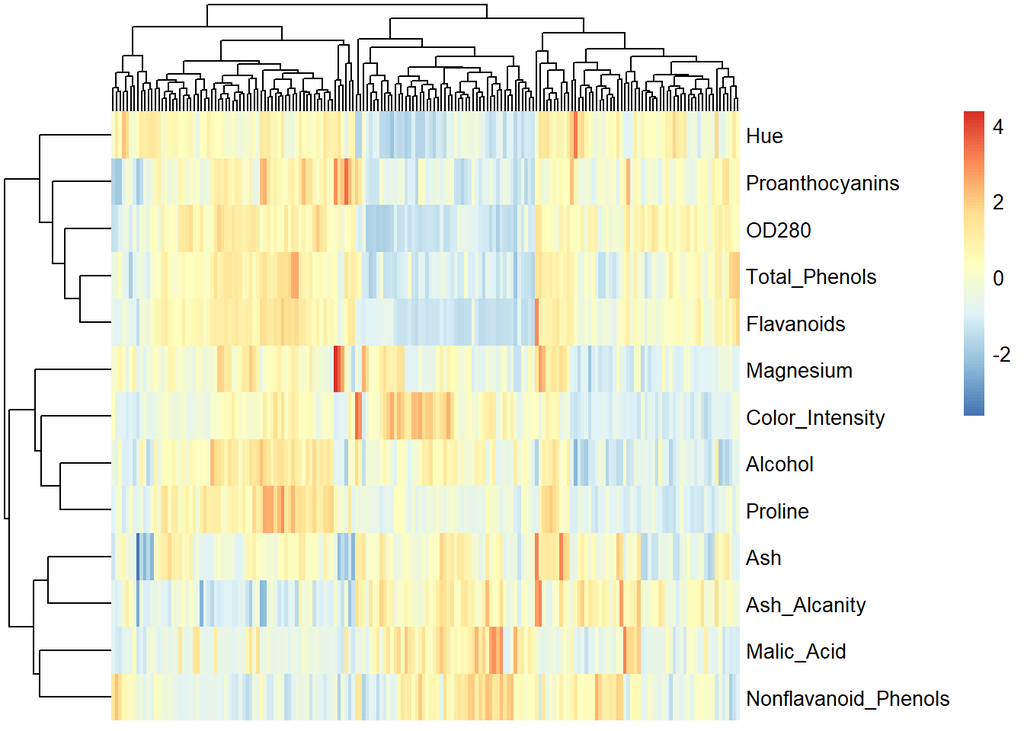

```r
pheatmap(t(wine_scaled), cuttree_cols=3)
```